# Iris Flower Data Clean-up

Sean F. Larsen

April 2, 2019

## Ronald Fisher’s Iris Flower Dataset

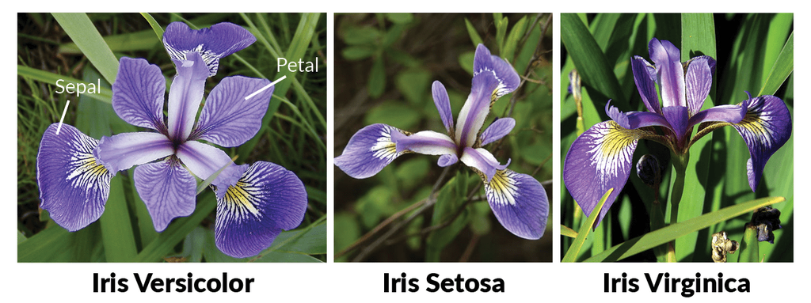

The Iris Flower dataset was introduced by the British statistician and biologist Ronald Fisher in his 1936 paper The use of multiple measurements in taxonomic problems as an example of linear discriminant analysis.

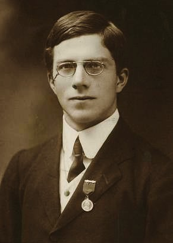

**RONALD FISHER 1913**

The Iris data is a favorite example when writing about R accessors , Data Exporting, Data importing, and for different visualization techniques. It is often used for examples in machine learning.

## The Dataset

Th Iris data set gives the measurements in centimeters of the variables sepal length and width and petal length and width, respectively, for 50 flowers from each of 3 species of iris. The species are Iris setosa, versicolor, and virginica. The data set has 150 cases (rows) and 5 variables (columns) named Sepal.Length, Sepal.Width, Petal.Length, Petal.Width, and Species.

I aquired the dataset online in a CSV format. Using the gather fuction tydyr, I will clean up the data and create a dataframe iris_df. The new data frame will have 600 rows and four columns.

Here is a Scatter Plot of the Sepal and Pedal features of the three Species.

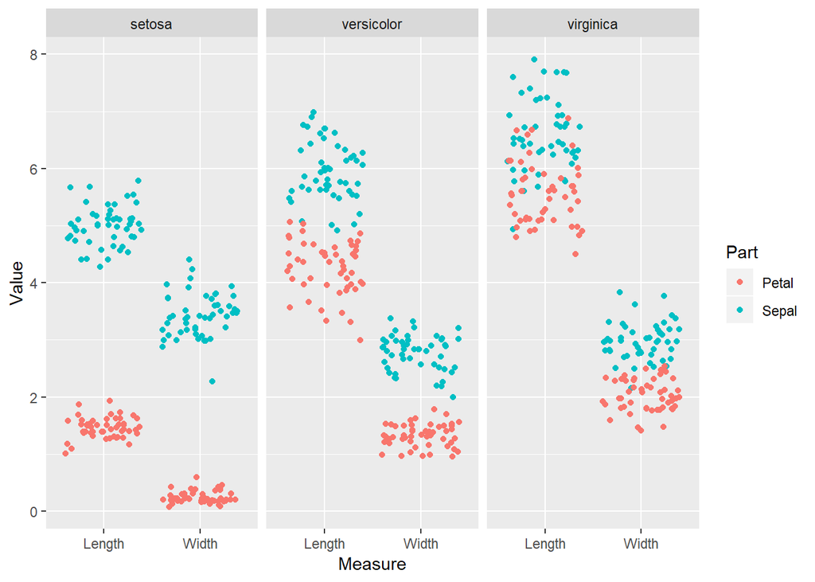

## The Decision Tree and Machine Learning

The Iris data set is perfect data set for demonstrating the decsion tree machine learning algorithm. A decision tree is a tool that uses a tree like model set of decisions that lead the user to the answer. Decision trees are commonly used in operations research, specifically in decision analysis, to help identify a strategy most likely to reach a goal.

The benefits of the descision tree is that they are easy to understand an interpret, thye work with categorical and numerical data, they require little data processing, and feature selection is automatic. They are not susceptible to outliers and are able to capture nonlinear relationships. The downside of descision trees is they are prone to over fitting and with large complex data sets can be inaccurate.

## Training Test Split

Here we are taking the iris_df data frame and spliting it into two new file, iris_training to train the model and iris_test to test the model. The training data will contain 80% of the original data and the test model will contain 20%. This model will be used to determine which species of iris a flower is, so the test data will not contain the species column. This model uses the information index in the split criterion and the Complexity Parameter to measure to control tree growth. CP is first set to zero.

Once the data is trained and tested the model, the decision tree will be plotted and then evaluated with a confusion matrix to display the results.

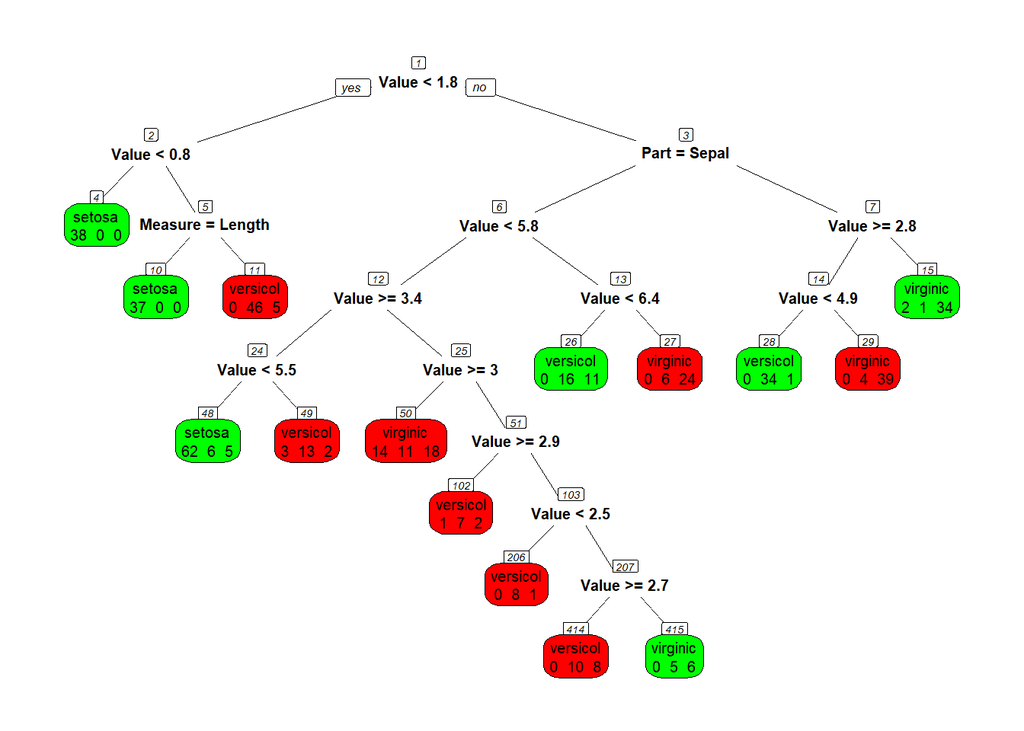

```
## Confusion Matrix and Statistics
##
##             Reference
## Prediction   setosa versicolor virginica
##   setosa         37          1         1
##   versicolor      3         21        11
##   virginica       3         11        32
##
## Overall Statistics
##
##                Accuracy : 0.75
##                  95% CI : (0.6627, 0.8245)
##     No Information Rate : 0.3667
##     P-Value [Acc > NIR] : <2e-16
##
##                   Kappa : 0.6228
##
##  Mcnemar's Test P-Value : 0.5724
##
## Statistics by Class:
##
##                      Class: setosa Class: versicolor Class: virginica
## Sensitivity                 0.8605            0.6364           0.7273
## Specificity                 0.9740            0.8391           0.8158
## Pos Pred Value              0.9487            0.6000           0.6957
## Neg Pred Value              0.9259            0.8588           0.8378
## Prevalence                  0.3583            0.2750           0.3667
## Detection Rate              0.3083            0.1750           0.2667
## Detection Prevalence        0.3250            0.2917           0.3833
## Balanced Accuracy           0.9172            0.7377           0.7715
```

## First Run of the Model

If you look at the scatter plot, you see that the Iris Species versicolor and virginica are very similar. At first pass, this model is 75% accurate. For the setosa speicies it was the most accurate.

To better evalue this model, the next steop would be to look at CP. The xerror, is the optimal value for CP. The model accuracy is calculated and stored in variable base_accuracy.

```
##
## Classification tree:
## rpart(formula = Species ~ ., data = iris_train, method = "class",
##     parms = list(split = "information"), control = rpart.control(cp = 0))
##
## Variables actually used in tree construction:
## [1] Measure Part    Value
##
## Root node error: 313/480 = 0.65208
##
## n= 480
##
##         CP nsplit rel error  xerror     xstd
## 1 0.188498      0   1.00000 1.03834 0.032730
## 2 0.073482      1   0.81150 0.88498 0.034580
## 3 0.060703      3   0.66454 0.66134 0.034666
## 4 0.052716      6   0.46006 0.57827 0.033924
## 5 0.031949      8   0.35463 0.39297 0.030558
## 6 0.022364      9   0.32268 0.39617 0.030639
## 7 0.015974     10   0.30032 0.36422 0.029787
## 8 0.001065     11   0.28435 0.33866 0.029035
## 9 0.000000     14   0.28115 0.38019 0.030225
```

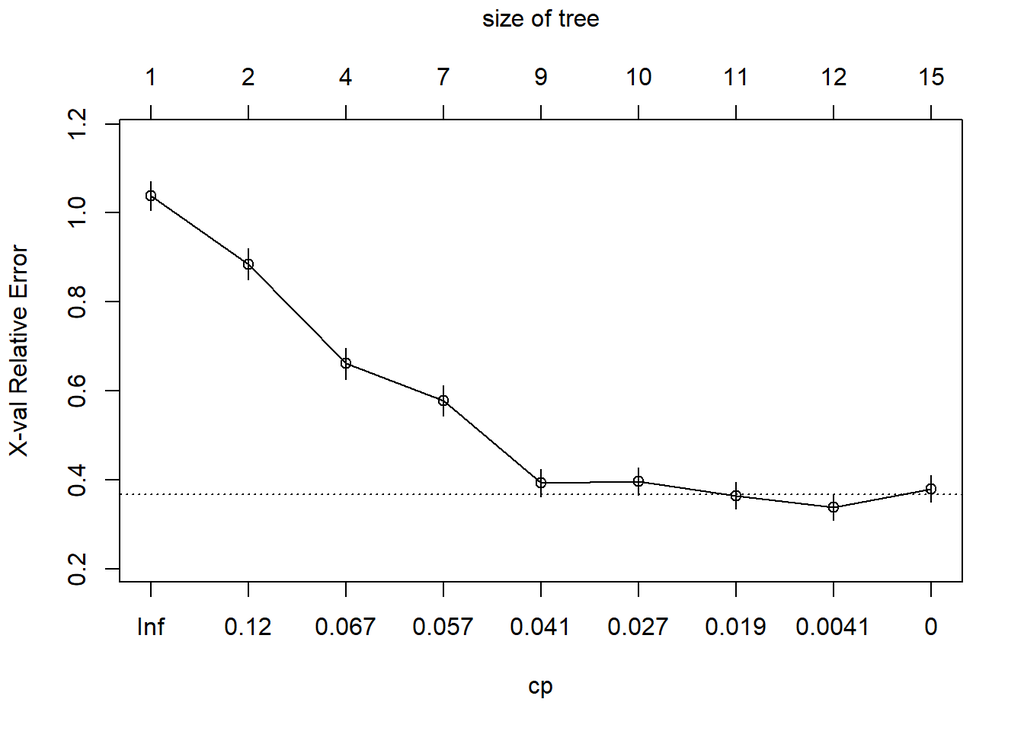

## Pruning the Tree

One problem to avoid is over fitting the model and this is done with pruning. There are two types of pruning. Pre-pruning and Post-pruning. Pre-pruning is a stopr criteria built into rpart. I am setting the CP to 0, the mex depth to 8 and the min spilt to 50.

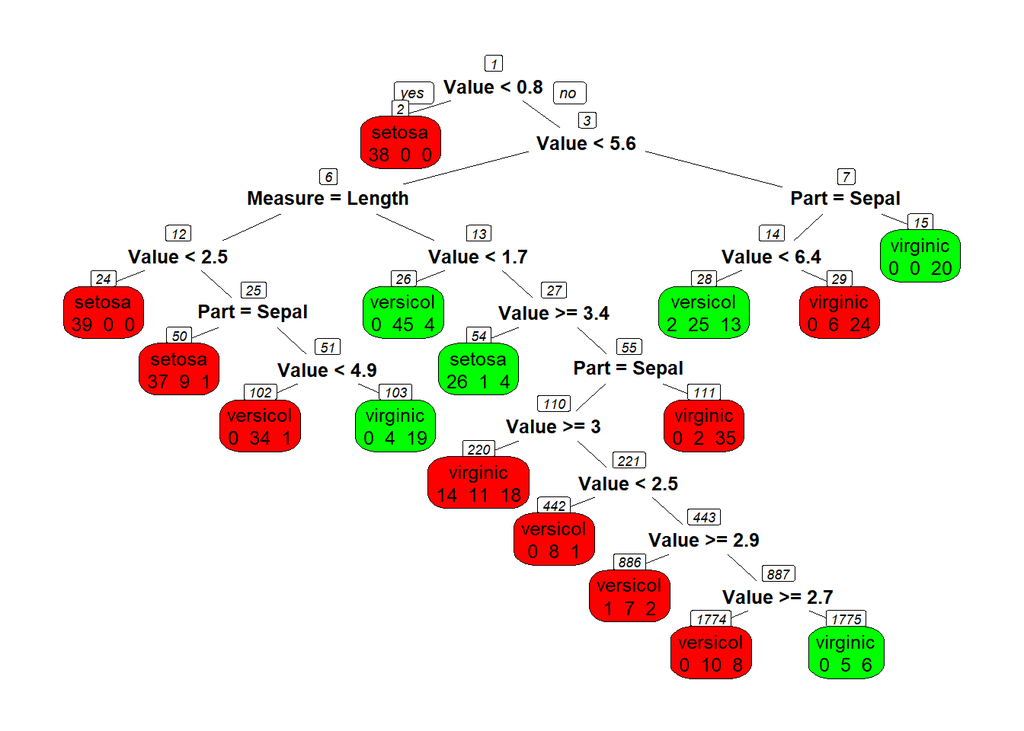

```
## Confusion Matrix and Statistics
##
##             Reference
## Prediction   setosa versicolor virginica
##   setosa         38          2         1
##   versicolor      2         20        11
##   virginica       3         11        32
##
## Overall Statistics
##
##                Accuracy : 0.75
##                  95% CI : (0.6627, 0.8245)
##     No Information Rate : 0.3667
##     P-Value [Acc > NIR] : <2e-16
##
##                   Kappa : 0.622
##
##  Mcnemar's Test P-Value : 0.8013
##
## Statistics by Class:
##
##                      Class: setosa Class: versicolor Class: virginica
## Sensitivity                 0.8837            0.6061           0.7273
## Specificity                 0.9610            0.8506           0.8158
## Pos Pred Value              0.9268            0.6061           0.6957
## Neg Pred Value              0.9367            0.8506           0.8378
## Prevalence                  0.3583            0.2750           0.3667
## Detection Rate              0.3167            0.1667           0.2667
## Detection Prevalence        0.3417            0.2750           0.3833
## Balanced Accuracy           0.9224            0.7283           0.7715
```

```
##
## Classification tree:
## rpart(formula = Species ~ ., data = iris_train, method = "class",
##     control = rpart.control(cp = 0), maxdepth = 8, minsplit = 50)
##
## Variables actually used in tree construction:
## [1] Measure Part    Value
##
## Root node error: 313/480 = 0.65208
##
## n= 480
##
##         CP nsplit rel error  xerror     xstd
## 1 0.121406      0   1.00000 1.00000 0.033340
## 2 0.090522      1   0.87859 0.88179 0.034602
## 3 0.070288      4   0.60703 0.67093 0.034724
## 4 0.060703      5   0.53674 0.56869 0.033810
## 5 0.047923      7   0.41534 0.48562 0.032561
## 6 0.020767      8   0.36741 0.38658 0.030393
## 7 0.019169     10   0.32588 0.39617 0.030639
## 8 0.001065     12   0.28754 0.31629 0.028321
## 9 0.000000     15   0.28435 0.34824 0.029325
```

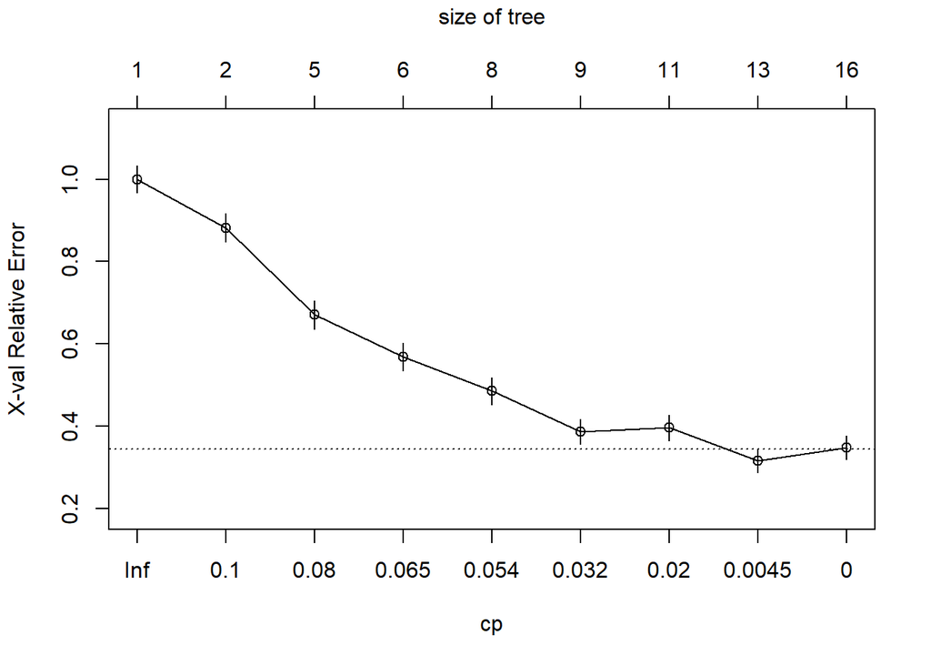

With the Pre-Pruning results, we can see that the overall accuracy didn’t improve. For the most part each speicies results remained the same.